# QLearning en el problema Taxi-v3

*Description:* Comparación experimental de Q-Learning y Double Q-Learning en el entorno Taxi-v3. Se analizan recompensa promedio, longitud de episodio y estabilidad de convergencia bajo política $\epsilon$-greedy con decaimiento.

```
Authors: Ginés Carrillo Ibáñez, Yago Ibarrola Lapeña, Aarón Palomar Peña
Emails: gines.carrilloi@um.es, yago.ibarrolal@um.es, aaron.p.p@um.es
Date: 2026/02/22
```

## Preparación del entorno

```python
# #@title Copiar el repositorio.
# print("Clonando el repositorio, tiempo estimado: 1-2 minutos...")
# !git clone https://github.com/YagoIbarrola/EML_Carrillo_Ibarrola_Palomar.git
# !cd EML_Carrillo_Ibarrola_Palomar/

# #@title Importamos todas las clases y funciones
# import sys
# # Añadir los directorio fuentes al path de Python
# sys.path.append('/content/EML_Carrillo_Ibarrola_Palomar/entornos_complejos/src/')
# # Verificar que se han añadido correctamente
# print(sys.path)

# !pip install -r ./EML_Carrillo_Ibarrola_Palomar/requirements.txt

dir_base = "./EML_Carrillo_Ibarrola_Palomar/entornos_complejos"
```

```python
from agents import TaxiAgentQLearning, TaxiAgentDoubleQLearning
import gymnasium as gym
import numpy as np

from tqdm import tqdm  # Progress bar

from utils import plot_training_metrics, plot_training_metrics_multi, save_state, save_training_metrics, load_training_metrics

# Garantizamos reproducibilidad
import random
SEED = 42
random.seed(SEED)
np.random.seed(SEED)
```

## Experimento

El experimento compara el rendimiento de los algoritmos **Q-Learning** y **Double Q-Learning** en el entorno **Taxi-v3**, un problema de Aprendizaje por Refuerzo tabular con espacio de estados discreto.

Este entorno consta de:

- Espacio de estados: 500 estados discretos (según las 25 posiciones del taxi y las 5 posiciones del pasajero y las 4 ubicaciones de destino).
- Espacio de acciones: 6 acciones discretas (izquierda, derecha, arriba, abajo, recoger pasajero, dejar pasajero).
- Recompensa:
  - -1 por paso.
  - +20 por dejar correctamente al pasajero.
  - -10 por recoger/dejar ilegalmente (en una celda diferente a las 4 asignadas, sin pasajero o destino).
- El episodio termina cuando el pasajero es entregado correctamente o al alcanzar el límite de pasos (200).

A diferencia de un *k-armed bandit*, aquí el agente interactúa con un **MDP**, por lo que las acciones afectan al estado futuro y la política debe aprenderse sobre la dinámica del entorno.

El objetivo del experimento es analizar:

- Convergencia de la recompensa media por episodio.
- Evolución de la longitud de los episodios.
- Error diferencial (lo que cambia el valor un estado respecto al valor anterior).
- Diferencias entre Q-Learning y Double Q-Learning.
- Influencia de hiperparámetros como $\alpha$, $\epsilon$, $\gamma$.

## Ejecución del experimento

Se entrena cada agente durante:

- `n_episodes` episodios, tasa de aprendizaje `learning_rate` y factor de descuento `discount_factor`. Determinados mediante grid search.
- Exploración inicial $\epsilon_0 = 1.0$.
- Decaimiento lineal hasta $\epsilon_{min}$.
- Política epsilon-greedy.

En cada episodio:

1. Se resetea el entorno.
2. Se toman acciones según la política del agente (en este caso, epsilon-greedy).
3. Se actualizan las tablas Q (mediante el algoritmo Q-Learning).
4. Al llegar al final del episodio, se reduce $\epsilon$ (decaimiento lineal).

### Experimento 1: Q-Learning

```python
def train_agent(agent, n_episodes):
    key_episodes = [[] for _ in range(10)]
    env = agent.env  # Access the environment from the agent
    for t in tqdm(range(n_episodes)):
        # Start a new episode
        state, info = env.reset(seed=SEED if t==0 else None)  # Reproducibilidad en el estado inicial
        done = False

        # Play one complete episode

        while not done:
            # Agent chooses action (initially random, gradually more intelligent)
            action, is_exploring = agent.get_action(state)

            if t % (n_episodes // 10) == 0:
                # key_episodes[t // (n_episodes // 10)].append((state, is_exploring))
                save_state(
                    agent=agent,
                    is_exploring=is_exploring,
                    obs=state,
                    episode_history=key_episodes[t // (n_episodes // 10)]
                )
            # Take action and observe result
            next_state, reward, terminated, truncated, info = env.step(action)

            # Learn from this experience
            agent.update(state, action, reward, terminated, next_state)

            # Move to next state
            done = terminated or truncated
            state = next_state

        # Reduce exploration rate (agent becomes less random over time)
        agent.decay_epsilon()
    return key_episodes
```

#### Grid Search

Se realiza un grid search para determinar los mejores hiperparámetros de Q-Learning. Se evalúan diferentes combinaciones de `learning_rate` y `n_episodes_grid` episodios, guardando la recompensa media obtenida, el porcentaje de episodios exitosos (con recompensa positiva) y la desviación típica de las recompensas.

```python
# Grid de hiperparámetros
learning_rates = [0.016, 0.032, 0.064, 0.128, 0.256, 0.512, 1]
n_episodes_grid = [1000, 2000, 3000, 4000, 5000, 6000, 7000]

start_epsilon = 1.0
final_epsilon = 0.1
```

```python
def grid_search(agent_class, learning_rates, n_episodes_grid):
    results_matrix = np.zeros((len(learning_rates), len(n_episodes_grid), 3))  # 3 for win_rate, avg_reward, std_reward
    for i, lr in enumerate(learning_rates):
        for j, n_episodes in enumerate(n_episodes_grid):

            print(f"\nTraining with lr={lr}, episodes={n_episodes}")

            epsilon_decay = start_epsilon / (n_episodes / 2)
            # ratio = 0.5 # Fraccion del entrenamiento previo al epsilon minimo
            # epsilon_decay = (start_epsilon / final_epsilon - 1)/(n_episodes * ratio)

            # Crear entorno nuevo en cada combinación
            env = gym.make("Taxi-v3")
            env = gym.wrappers.RecordEpisodeStatistics(env, buffer_length=n_episodes)

            agent = agent_class(
                env=env,
                learning_rate=lr,
                epsilon=start_epsilon,
                epsilon_decay=epsilon_decay,
                final_epsilon=final_epsilon,
            )

            train_agent(agent, n_episodes)

            # Evaluación
            win_rate, avg_reward, std_reward = agent.test(num_episodes=1000)

            results_matrix[i, j] = win_rate, avg_reward, std_reward

            print(f"Avg reward: {avg_reward}")
            print(f"Win rate: {win_rate}")
            print(f"Std reward: {std_reward}")
    return results_matrix
```

```python
%%capture
results_matrix = grid_search(TaxiAgentQLearning, learning_rates, n_episodes_grid)
```

```python
import matplotlib.pyplot as plt
import seaborn as sns

def plot_results_matrix(results_matrix, learning_rates, n_episodes_grid):
    avg_rewards = results_matrix[:, :, 1]  # Extract average rewards
    win_rates = results_matrix[:, :, 0]     # Extract win rates
    std_rewards = results_matrix[:, :, 2]   # Extract standard deviation of rewards
    # Create a heatmap of average rewards
    plt.figure(figsize=(10, 6))
    sns.heatmap(avg_rewards, annot=True, fmt=".2f", xticklabels=n_episodes_grid, yticklabels=learning_rates)
    plt.title("Average Rewards for Different Learning Rates and Episodes")
    plt.xlabel("Number of Episodes")
    plt.ylabel("Learning Rate")
    plt.show()

    # Create a heatmap of win rates
    plt.figure(figsize=(10, 6))
    sns.heatmap(win_rates, annot=True, fmt=".2f", xticklabels=n_episodes_grid, yticklabels=learning_rates)
    plt.title("Win Rates for Different Learning Rates and Episodes")
    plt.xlabel("Number of Episodes")
    plt.ylabel("Learning Rate")
    plt.show()

    # Create a heatmap of standard deviation of rewards
    plt.figure(figsize=(10, 6))
    sns.heatmap(std_rewards, annot=True, fmt=".2f", xticklabels=n_episodes_grid, yticklabels=learning_rates)
    plt.title("Standard Deviation of Rewards for Different Learning Rates and Episodes")
    plt.xlabel("Number of Episodes")
    plt.ylabel("Learning Rate")
    plt.show()
```

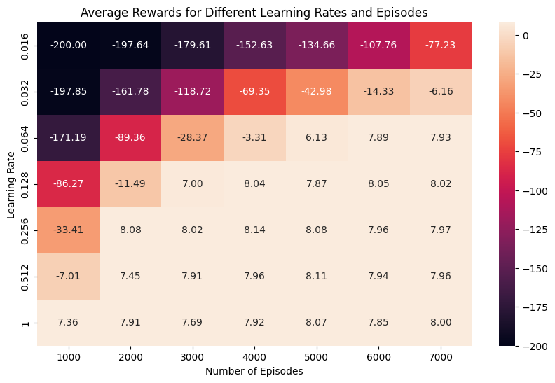

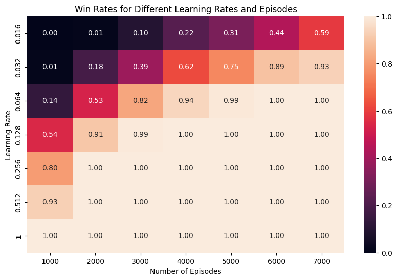

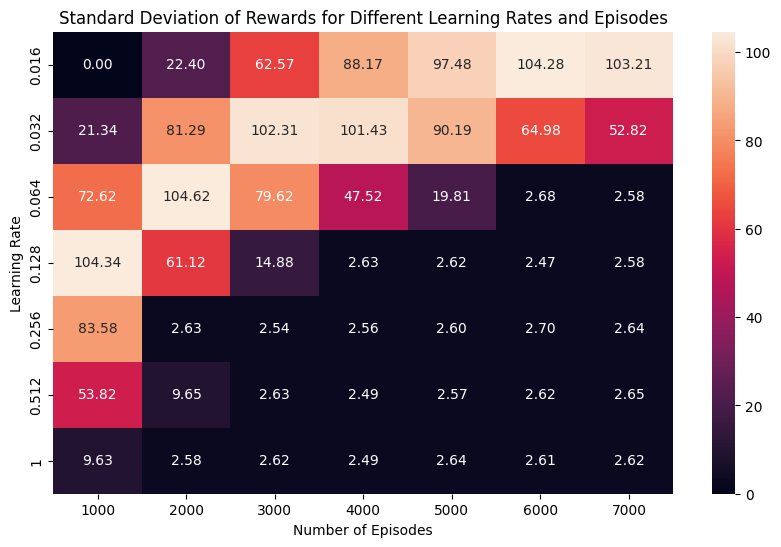

```python
plot_results_matrix(results_matrix, learning_rates, n_episodes_grid)
```

En base a los resultados del grid search, se seleccionan los mejores hiperparámetros para el entrenamiento final. En base a la recompensa promedio, win rate (episodios con recompensa positiva, ya que en una mala situación, el taxi tendría que moverse 19 celdas pero ganaría 20 al entregar al pasajero) y desviación típica de las recompensas, si optamos por el menor número de episodios con una tasa de aprendizaje moderada, la mejor opción es `learning_rate = 0.256` y `n_episodes_grid = 2000`.

A continuación, se experimenta variando el valor del parámetro de descuento $\gamma$ para analizar su impacto en el rendimiento del agente.

```python
discount_factors = [0.8, 0.85, 0.9, 0.95, 0.99]
results_array = np.zeros((len(discount_factors)))

n_episodes = 2000
lr = 0.256
epsilon_decay = start_epsilon / (n_episodes / 2)
# ratio = 0.5 # Fraccion del entrenamiento previo al epsilon minimo
# epsilon_decay = (start_epsilon / final_epsilon - 1)/(n_episodes * ratio)

for i, discount_factor in enumerate(discount_factors):
    print(f"\nTraining with discount_factor={discount_factor}")
    # Crear entorno nuevo en cada combinación
    env = gym.make("Taxi-v3")
    env = gym.wrappers.RecordEpisodeStatistics(env, buffer_length=n_episodes)

    agent = TaxiAgentQLearning(
        env=env,
        learning_rate=lr,
        epsilon=start_epsilon,
        epsilon_decay=epsilon_decay,
        final_epsilon=final_epsilon,
        discount_factor=discount_factor,
    )

    train_agent(agent, n_episodes)

    # Evaluación
    win_rate, avg_reward, std_reward = agent.test(num_episodes=1000)

    results_array[i] = avg_reward

    print(f"Avg reward: {avg_reward}")
```

```
Training with discount_factor=0.8
```

```
Test Results over 1000 episodes:
Win Rate: 97.7%
Average Reward: 3.190
Standard Deviation: 31.289
Avg reward: 3.19

Training with discount_factor=0.85
```

```
Test Results over 1000 episodes:
Win Rate: 97.0%
Average Reward: 1.795
Standard Deviation: 35.578
Avg reward: 1.795

Training with discount_factor=0.9
```

```
Test Results over 1000 episodes:
Win Rate: 99.3%
Average Reward: 6.716
Standard Deviation: 17.558
Avg reward: 6.716

Training with discount_factor=0.95
```

```
Test Results over 1000 episodes:
Win Rate: 100.0%
Average Reward: 8.100
Standard Deviation: 2.654
Avg reward: 8.1

Training with discount_factor=0.99
```

```
Test Results over 1000 episodes:
Win Rate: 99.5%
Average Reward: 7.135
Standard Deviation: 14.916
Avg reward: 7.135
```

Atendiendo a los resultados de arriba, mantenemos el `discount_factor` por defecto (0.95), que es el valor que mejor rendimiento ha dado.

#### Agente óptimo

Se construye el agente con los mejores hiperparámetros encontrados. Se analizan las métricas de entrenamiento (recompensa media, longitud de episodio, error diferencial) y se evalúa el agente en 1000 episodios de test para medir su rendimiento final.

```python
# Training hyperparameters
learning_rate = 0.256        # How fast to learn (higher = faster but less stable)
n_episodes = 2000        # Number of hands to practice
start_epsilon = 1.0         # Start with 100% random actions
epsilon_decay = start_epsilon / (n_episodes / 2)  # Reduce exploration over time
# ratio = 0.5 # Fraccion del entrenamiento previo al epsilon minimo
# epsilon_decay = (start_epsilon / final_epsilon - 1)/(n_episodes * ratio)
final_epsilon = 0.1         # Always keep some exploration
discount_factor = 0.95     # How much to value future rewards (0.9 = 90%)

# Create environment and agent
env = gym.make("Taxi-v3")
env = gym.wrappers.RecordEpisodeStatistics(env, buffer_length=n_episodes)

agent = TaxiAgentQLearning(
    env=env,
    learning_rate=learning_rate,
    epsilon=start_epsilon,
    epsilon_decay=epsilon_decay,
    final_epsilon=final_epsilon,
    discount_factor=discount_factor,
)

best_key_episodes = train_agent(agent, n_episodes)
```

#### Visualización de los resultados

La función `plot_training_metrics` representa:

- Recompensa media por episodio (suavizada, es decir, con una media móvil).
- Longitud media del episodio.
- Error TD acumulado (estabilidad del aprendizaje).

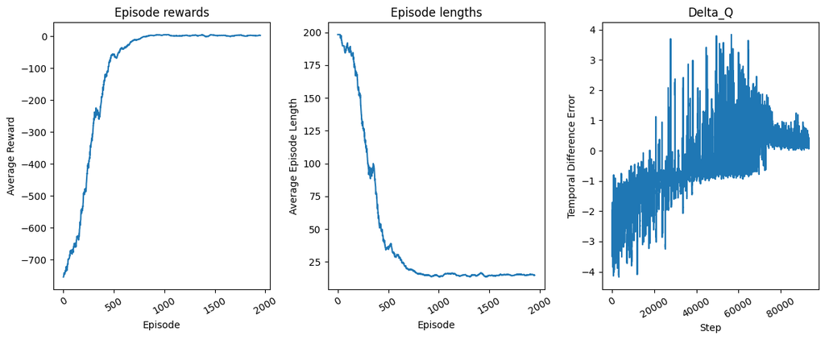

```
Test Results over 1000 episodes:
Win Rate: 99.5%
Average Reward: 7.038
Standard Deviation: 14.914
```

```python
plot_training_metrics(env.return_queue, env.length_queue, agent.training_error, rolling_length=50)

save_training_metrics(env.return_queue, env.length_queue, agent.training_error, filename=dir_base+"/data/results/QLearning/experiment1_metrics.npz")

agent.test(num_episodes=1000)
print()
```

#### Análisis detallado de la imagen

**Recompensa promedio por episodio**

La gráfica muestra la evolución de la recompensa promedio a lo largo del entrenamiento.

En **Taxi-v3**, una política óptima obtiene recompensas cercanas a valores cercanos a cero, ya que:

- Cada movimiento cuesta -1.
- El agente necesita varios pasos para completar la tarea.
- Solo al final recibe +20.

Al inicio, la recompensa es muy negativa (política casi aleatoria). Conforme disminuye $\epsilon$, la recompensa mejora. El agente aprende a evitar recogidas/entregas ilegales y a minimizar pasos innecesarios.

**Longitud del episodio**

Inicialmente los episodios son largos (muchos movimientos aleatorios).

Con el aprendizaje:

- El número de pasos disminuye.
- El agente encuentra trayectorias más cortas.
- Se acerca al comportamiento óptimo.

Por tanto, el agente ha aprendido el entorno.

**Estabilidad delta**

El error TD mide:

$$ \delta = r + \gamma \max_{a'} Q(s',a') - Q(s,a) $$

Al inicio el error es grande y las estimaciones Q cambian significativamente. Sin embargo, conforme el agente aprende, el error TD disminuye y se estabiliza.

#### Experimento 1B: Epsilon decay inversamente proporcional

Otro experimento interesante a realizar es comparar el decaimiento lineal de $\epsilon$ con un decaimiento inversamente proporcional al número de episodios, es decir, $\epsilon = \frac{\epsilon_0}{1 + epsilon\_decay \cdot episode}$, donde `epsilon_decay` controla la velocidad de decaimiento. Esto permite una exploración más prolongada en las primeras etapas del entrenamiento y una convergencia más suave a medida que el agente aprende.

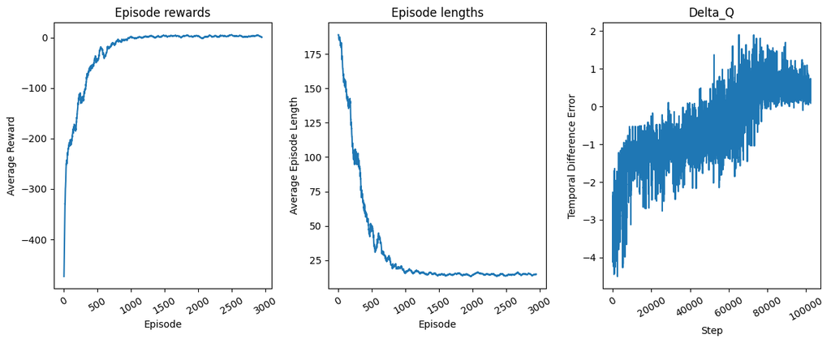

```
Test Results over 1000 episodes:
Win Rate: 99.7%
Average Reward: 7.151
Standard Deviation: 11.659
```

```python
# Training hyperparameters
learning_rate = 0.128        # How fast to learn (higher = faster but less stable)
n_episodes = 3000        # Number of hands to practice
start_epsilon = 1.0         # Start with 100% random actions
# epsilon_decay = start_epsilon / (n_episodes / 2)  # Reduce exploration over time
ratio = 0.5 # Fraccion del entrenamiento previo al epsilon minimo
epsilon_decay = (start_epsilon / final_epsilon - 1)/(n_episodes * ratio)
final_epsilon = 0.1         # Always keep some exploration
discount_factor = 0.95     # How much to value future rewards (0.9 = 90%)

# Create environment and agent
env = gym.make("Taxi-v3")
env = gym.wrappers.RecordEpisodeStatistics(env, buffer_length=n_episodes)

agent = TaxiAgentQLearning(
    env=env,
    learning_rate=learning_rate,
    epsilon=start_epsilon,
    epsilon_decay=epsilon_decay,
    final_epsilon=final_epsilon,
    discount_factor=discount_factor,
    decay_type="inverse"
)

key_episodes = train_agent(agent, n_episodes)

plot_training_metrics(env.return_queue, env.length_queue, agent.training_error, rolling_length=50)

# save_training_metrics(env.return_queue, env.length_queue, agent.training_error, filename=dir_base+"/data/results/QLearning/experiment1_metrics.npz")

agent.test(num_episodes=1000)
print()
```

No es una mejora significativa, por lo que se mantiene el decaimiento lineal para el resto de experimentos.

### Experimento 2: Double Q-Learning

En este experimento se siguen los mismos pasos que en el Experimento 1, pero utilizando el algoritmo Double Q-Learning, que utiliza dos tablas Q para reducir el sesgo de sobreestimación. Se realiza un grid search similar para encontrar los mejores hiperparámetros y se comparan las métricas de entrenamiento con las obtenidas por Q-Learning.

#### Grid Search

```python
%%capture
results_matrix_double = grid_search(TaxiAgentDoubleQLearning, learning_rates, n_episodes_grid)
```

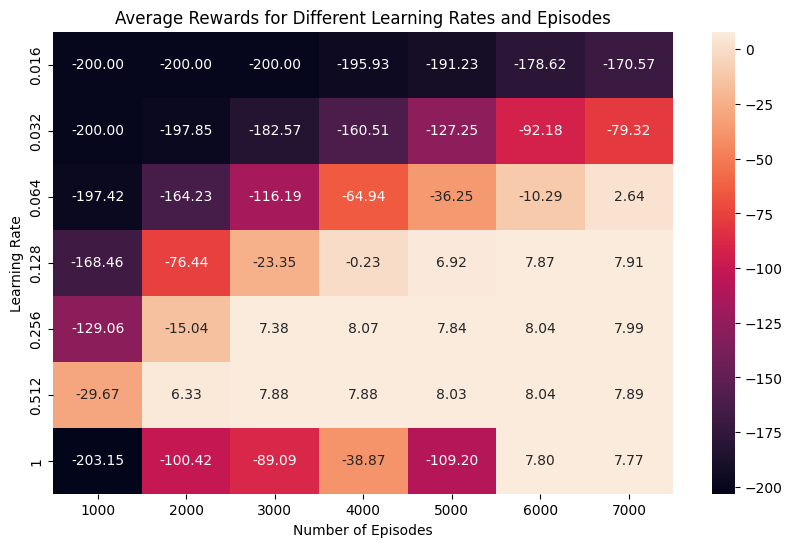

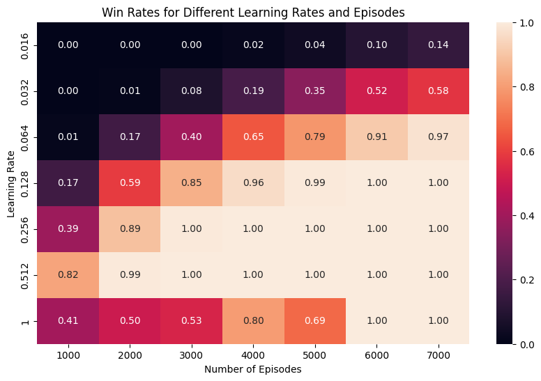

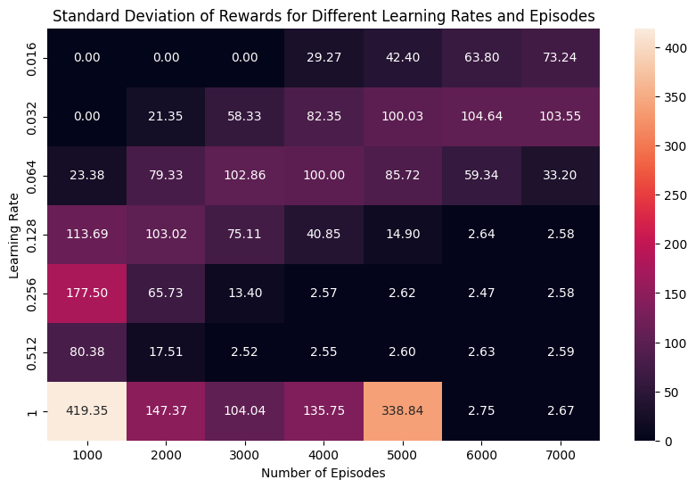

```python
plot_results_matrix(results_matrix_double, learning_rates, n_episodes_grid)
```

Es claro que un learning rate demasiado alto (1) provoca inestabilidad en el aprendizaje, con recompensas muy negativas y alta desviación típica. Por otro lado, un learning rate demasiado bajo (0.064) resulta en un aprendizaje muy lento, con recompensas bajas y alta variabilidad. El mejor rendimiento se obtiene con un learning rate de 0.256 y 0.512, que ofrece un buen equilibrio. Para que sea moderado, se escoge el valor de 0.256, y por tanto, un número de episodios de 4000, que es el valor que mejores recompensas media ha dado. Como se vio en el experimento anterior, es recomendable dejar el discount factor por defecto (0.95) y usar el epsilon decay lineal.

Por tanto, los parámetros son `learning_rate = 0.256`y `n_episodes = 4000`, justo el doble de episodios que en el experimento anterior. Esto puede ser debido a queDouble Q-Learning puede requerir más episodios para converger debido a la necesidad de actualizar dos tablas Q, aunque ya se vio en clase que mejoraba a Q-Learning incluso desde el inicio, por lo que este resultado está condicionado a que el entorno es muy sencillo y no hay mucha sobreestimación. Por tanto, el beneficio de Double Q-Learning no es tan evidente como en entornos más complejos.

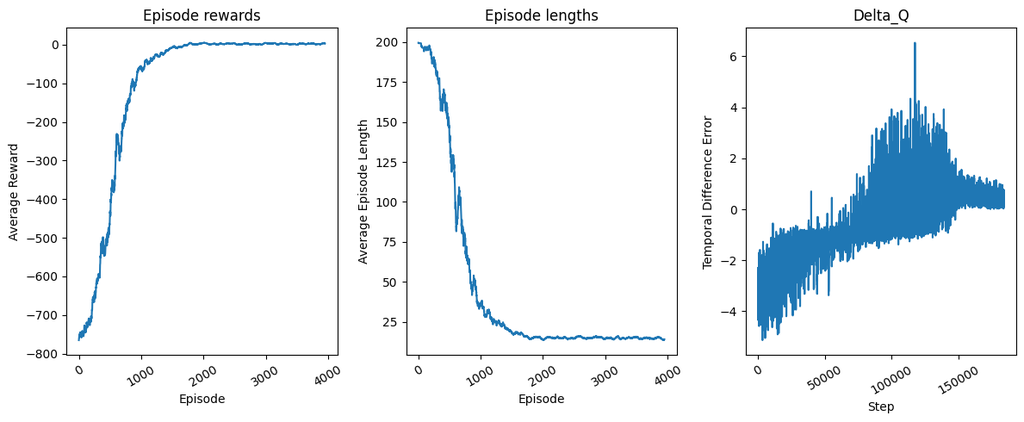

```
Test Results over 1000 episodes:
Win Rate: 100.0%
Average Reward: 8.101
Standard Deviation: 2.596
```

```python
# Training hyperparameters
learning_rate = 0.256        # How fast to learn (higher = faster but less stable)
n_episodes = 4000        # Number of hands to practice
start_epsilon = 1.0         # Start with 100% random actions
epsilon_decay = start_epsilon / (n_episodes / 2)  # Reduce exploration over time
# ratio = 0.5 # Fraccion del entrenamiento previo al epsilon minimo
# epsilon_decay = (start_epsilon / final_epsilon - 1)/(n_episodes * ratio)
final_epsilon = 0.1         # Always keep some exploration

# Create environment and agent
env = gym.make("Taxi-v3")
env = gym.wrappers.RecordEpisodeStatistics(env, buffer_length=n_episodes)

agent = TaxiAgentDoubleQLearning(
    env=env,
    learning_rate=learning_rate,
    epsilon=start_epsilon,
    epsilon_decay=epsilon_decay,
    final_epsilon=final_epsilon,
)

key_episodes = train_agent(agent, n_episodes)

plot_training_metrics(env.return_queue, env.length_queue, agent.training_error, rolling_length=50)
agent.test(num_episodes=1000)
print()
```

```python
# Para que sean comparables, ponemos el mismo decaimiento y episodios que en el experimento anterior
env_save = gym.make("Taxi-v3")
env_save = gym.wrappers.RecordEpisodeStatistics(env_save, buffer_length=2000)
agent_save = TaxiAgentDoubleQLearning(env=env_save,learning_rate=0.256,epsilon=1.0,epsilon_decay=1.0 / (2000 / 2), final_epsilon=0.1,)
train_agent(agent_save, 2000)
save_training_metrics(env_save.return_queue, env_save.length_queue, agent_save.training_error, filename=dir_base+"/data/results/QLearning/experiment2_metrics.npz")
```

## Comparación final

#### Comparación: Q-Learning vs Double Q-Learning

**Q-Learning**

En Q-Learning, la actualización de la tabla Q se realiza utilizando la siguiente fórmula:

$$ Q(s,a) \leftarrow Q(s,a) + \alpha [r + \gamma \max_{a'} Q(s',a') - Q(s,a)] $$

No obstante, este método sufre de un sesgo de sobreestimación debido a la operación max sobre las estimaciones Q, lo que puede llevar a valores Q positivos, mayor varianza y una convergencia menos estable. Como solución a este problema, se introdujo Double Q-Learning.

**Double Q-Learning**

Mantiene dos tablas $Q_1$ y $Q_2$:

- Una selecciona la acción.
- La otra evalúa su valor. Que se intercambian periódicamente (es decir, con un 50% de probabilidad se actualiza $Q_1$ usando $Q_2$ para la acción máxima, y con el 50% restante se actualiza $Q_2$ usando $Q_1$).

Esto reduce el sesgo por maximización, es decir, se obtiene una convergencia más estable y menor sobreestimación (a la larga).

No obstante, al darle el mismo número de episodios, Double Q-Learning tarda más en converger a una política óptima debido a la división de la información entre las dos tablas. Por tanto, con el mismo número de episodios, Q-Learning ofrece mejores resultados en este caso.

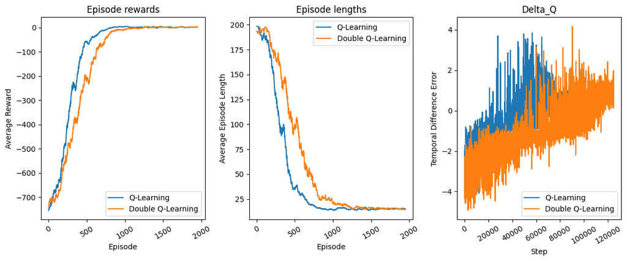

```python
experiment1 = load_training_metrics(filename=dir_base+"/data/results/QLearning/experiment1_metrics.npz")
experiment2 = load_training_metrics(filename=dir_base+"/data/results/QLearning/experiment2_metrics.npz")

# Hacemos las gráficas comparativas entre los experimentos
rewards1, lengths1, errors1 = experiment1
rewards2, lengths2, errors2 = experiment2

# Si quieres combinarlos en un solo gráfico
plot_training_metrics_multi(
    rewards_list=[rewards1, rewards2],
    lengths_list=[lengths1, lengths2],
    training_errors_list=[errors1, errors2],
    labels=["Q-Learning", "Double Q-Learning"],
    rolling_length=50
)
```

Aunque en el test Double Q-Learning obtiene una recompensa media ligeramente superior, la diferencia no es significativa. Además, Q-Learning converge más rápido a una política óptima, lo que se refleja en la evolución de la recompensa media y la longitud de los episodios. En resumen, aunque Double Q-Learning puede reducir el sesgo de sobreestimación, en este entorno específico y con el número de episodios utilizado, Q-Learning ofrece un mejor rendimiento.

## Animación de episodios clave

Se almacenan episodios cada 10% del entrenamiento.

Las animaciones muestran la política óptima aprendida por el agente (cambia según el estado del agente, es decir, cuando recoge al pasajero) en diferentes etapas del entrenamiento. En concreto:

- Al inicio: comportamiento errático debido a la alta exploración inicial.
- En fases intermedias: recogida correcta del pasajero pero trayectorias largas.
- Al final: ruta óptima de recogida y entrega.

```python
import importlib
import taxi_gif
# !pip install imageio
# !pip install gymansium[]
importlib.reload(taxi_gif)
print("Key episodes (every 10% of training):")
n_episodes = 2000
for i, episode in enumerate(best_key_episodes):
    print(f"Episode {i * (n_episodes // 10)}")
    taxi_gif.animar_estados_taxi_gif(episode_history=episode, nombre_archivo=fdir_base+"/data/gifs_taxi/QLearning/episode_{i * (n_episodes // 10)}.gif", fps=2)
```

```
Key episodes (every 10% of training):
Episode 0
```

[output not shown]

[output not shown]

[output not shown]

[output not shown]

[output not shown]

[output not shown]

[output not shown]

[output not shown]

[output not shown]

## Conclusiones

Hemos estudiado un problema de *Reinforcement Learning* completo modelado como un MDP discreto (Taxi-v3), comparando Q-Learning y Double Q-Learning.

### Q-Learning

- Aprende correctamente la política óptima.
- Puede sufrir ligera sobreestimación.
- Converge de forma estable en entorno tabular.

### Double Q-Learning

- Reduce el sesgo de maximización.
- Presenta mayor estabilidad.
- Necesita más iteraciones para converger.

En ambos casos, la elección de hiperparámetros afecta velocidad y estabilidad de la convergencia.

Respecto a la influencia de los hiperparámetros, se observa que:

#### Learning rate $\alpha$

Existe un compromiso clásico estabilidad-velocidad.

#### Exploración $\epsilon$

- $\epsilon$ alto al inicio:
  - Permite explorar el espacio de estados.
  - Evita políticas subóptimas tempranas.
- $\epsilon_{min} > 0$:
  - Mantiene exploración residual.
  - Puede ser útil si el entorno fuese estocástico.

En Taxi-v3 determinista, una vez aprendida la política óptima, la exploración residual puede penalizar ligeramente el rendimiento medio.

#### Discount factor $\gamma$

- Valores altos (0.95):
  - El agente valora recompensas futuras.
  - Adecuado para tareas secuenciales largas.
- Valores más bajos (0.8):
  - Favorecen recompensas inmediatas.
  - Pueden producir políticas ligeramente más cortoplacistas.

Dado que la recompensa grande (+20) está al final del episodio, un $\gamma$ alto es generalmente más apropiado.

En definitiva, el experimento demuestra el funcionamiento práctico de algoritmos clásicos de control en un entorno MDP discreto, evidenciando la importancia del equilibrio entre exploración, tasa de aprendizaje y factor de descuento para alcanzar una política óptima.